# Federal Reserve Interest Rate Hold Announcement

2025-07-16

On December 13, 2023, the Federal Reserve announced its third consecutive interest rate hold and also indicated the possibilities of interest rate cuts in 2024. This event reduced economic uncertainty and gave the potential for market valuations to improve.

```r
library("tidyquant")
```

```r
library("forecast")
library("zoo")
library("ggplot2")
library("stats")
library("tidyverse")
library("tidymodels")
library("caret")
library('dplyr')
library("corrplot")
```

## Time Series’ for Federal Reserve Interest Rate Hold

Below are the daily time series for the stock prices from the selected GICS sector companies.

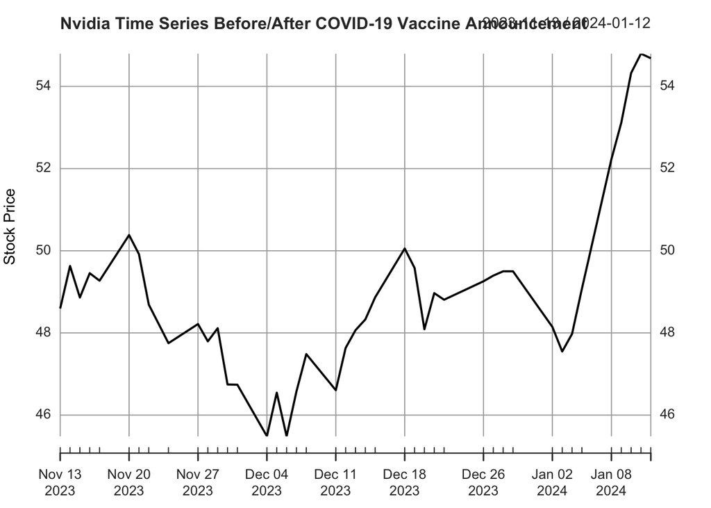

```r
##Nvidia
nvda_data<-tq_get("NVDA",get="stock.prices",complete_cases=TRUE,from="2023-11-13",to="2024-01-13")
xts_nvda<-xts(nvda_data$adjusted,order.by=nvda_data$date)
plot(xts_nvda,main="Nvidia Time Series Before/After COVID-19 Vaccine Announcement",xlab="Date",ylab="Stock Price")
```

```r
nvda_data
```

```
## # A tibble: 42 × 8
##    symbol date        open  high   low close    volume adjusted
##    <chr>  <date>     <dbl> <dbl> <dbl> <dbl>     <dbl>    <dbl>
##  1 NVDA   2023-11-13  48.3  49.1  48.1  48.6 384136000     48.6
##  2 NVDA   2023-11-14  49.7  49.8  49.0  49.7 416954000     49.6
##  3 NVDA   2023-11-15  49.9  50.0  48.2  48.9 475497000     48.9
##  4 NVDA   2023-11-16  48.7  49.5  48.3  49.5 339756000     49.5
##  5 NVDA   2023-11-17  49.5  49.7  49.0  49.3 325205000     49.3
##  6 NVDA   2023-11-20  49.3  50.5  49.2  50.4 414120000     50.4
##  7 NVDA   2023-11-21  50.1  50.5  49.2  49.9 565747000     49.9
##  8 NVDA   2023-11-22  49.9  50.3  47.7  48.7 899420000     48.7
##  9 NVDA   2023-11-24  48.5  48.9  47.7  47.8 294645000     47.8
## 10 NVDA   2023-11-27  47.8  48.5  47.7  48.2 395662000     48.2
## # ℹ 32 more rows
```

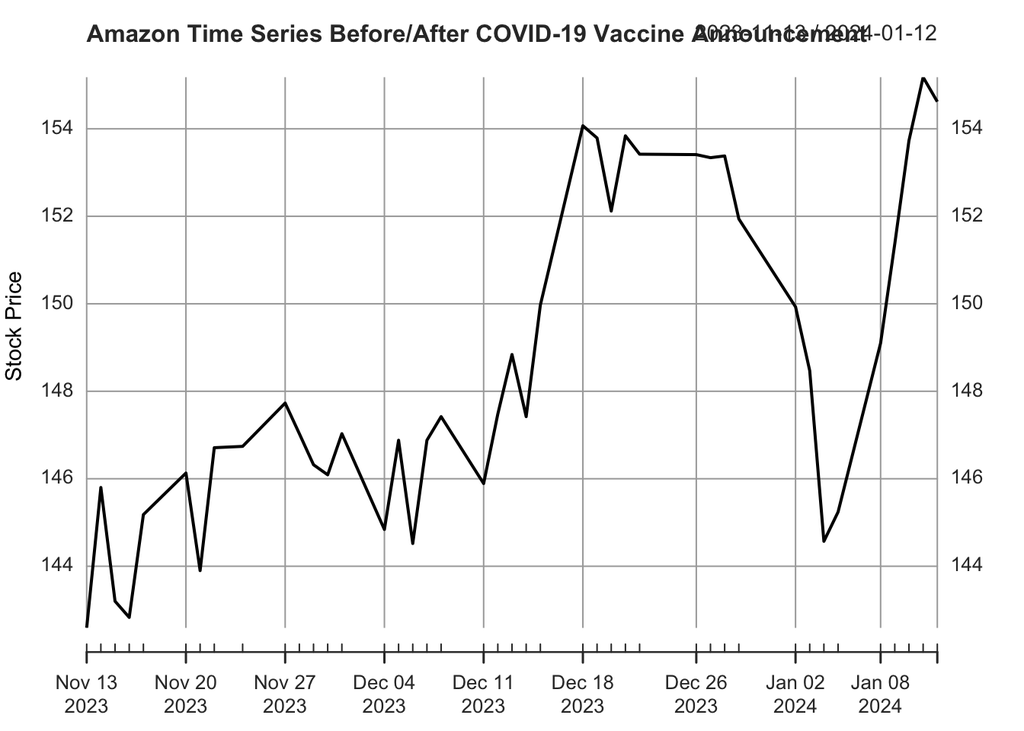

```r
##Amazon
amzn_data<-tq_get("AMZN",get="stock.prices",complete_cases=TRUE,from="2023-11-13",to="2024-01-13")
xts_amzn<-xts(amzn_data$adjusted,order.by=amzn_data$date)
plot(xts_amzn,main="Amazon Time Series Before/After COVID-19 Vaccine Announcement",xlab="Date",ylab="Stock Price")
```

```r
amzn_data
```

```
## # A tibble: 42 × 8
##    symbol date        open  high   low close   volume adjusted
##    <chr>  <date>     <dbl> <dbl> <dbl> <dbl>    <dbl>    <dbl>
##  1 AMZN   2023-11-13  142.  143.  141.  143. 35680600     143.
##  2 AMZN   2023-11-14  145   147.  145.  146. 56674600     146.
##  3 AMZN   2023-11-15  147.  147.  143.  143. 63875700     143.
##  4 AMZN   2023-11-16  141.  143.  140.  143. 49653500     143.
##  5 AMZN   2023-11-17  143.  145.  143.  145. 49636700     145.
##  6 AMZN   2023-11-20  145.  147.  145.  146. 41951200     146.
##  7 AMZN   2023-11-21  144.  144.  142.  144. 71226000     144.
##  8 AMZN   2023-11-22  145.  148.  145.  147. 45669100     147.
##  9 AMZN   2023-11-24  147.  147.  145.  147. 22378400     147.
## 10 AMZN   2023-11-27  148.  149.  147.  148. 53762400     148.
## # ℹ 32 more rows
```

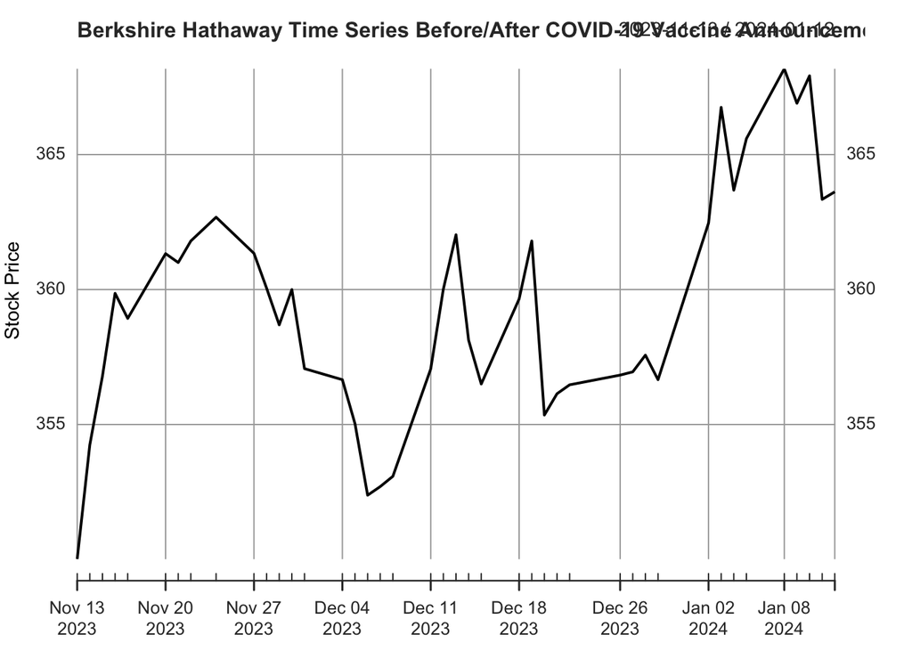

```r
##Berkshire Hathaway
brkb_data<-tq_get("BRK-B",get="stock.prices",complete_cases=TRUE,from="2023-11-13",to="2024-01-13")
xts_brkb<-xts(brkb_data$adjusted,order.by=brkb_data$date)
plot(xts_brkb,main="Berkshire Hathaway Time Series Before/After COVID-19 Vaccine Announcement",xlab="Date",ylab="Stock Price")
```

```r
brkb_data
```

```
## # A tibble: 42 × 8
##    symbol date        open  high   low close  volume adjusted
##    <chr>  <date>     <dbl> <dbl> <dbl> <dbl>   <dbl>    <dbl>
##  1 BRK-B  2023-11-13  350.  351.  349.  350. 2196200     350.
##  2 BRK-B  2023-11-14  353.  356.  351.  354. 3387500     354.
##  3 BRK-B  2023-11-15  355.  357.  354.  357. 3572900     357.
##  4 BRK-B  2023-11-16  358.  360   357.  360. 2822500     360.
##  5 BRK-B  2023-11-17  360.  361.  358.  359. 3260000     359.
##  6 BRK-B  2023-11-20  359.  363.  358.  361. 3215300     361.
##  7 BRK-B  2023-11-21  361.  363.  360.  361  2918800     361
##  8 BRK-B  2023-11-22  362.  362.  360.  362. 2110200     362.
##  9 BRK-B  2023-11-24  363.  363.  361.  363. 1282000     363.
## 10 BRK-B  2023-11-27  363.  363.  360.  361. 2580300     361.
## # ℹ 32 more rows
```

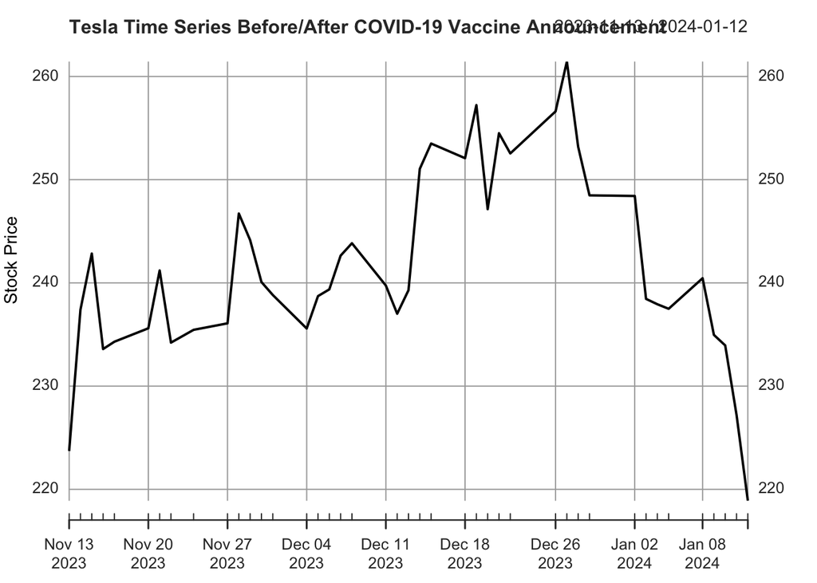

```r
##Tesla
tsla_data<-tq_get("TSLA",get="stock.prices",complete_cases=TRUE,from="2023-11-13",to="2024-01-13")
xts_tsla<-xts(tsla_data$adjusted,order.by=tsla_data$date)
plot(xts_tsla,main="Tesla Time Series Before/After COVID-19 Vaccine Announcement",xlab="Date",ylab="Stock Price")
```

```r
tsla_data
```

```
## # A tibble: 42 × 8
##    symbol date        open  high   low close    volume adjusted
##    <chr>  <date>     <dbl> <dbl> <dbl> <dbl>     <dbl>    <dbl>
##  1 TSLA   2023-11-13  216.  225.  212.  224. 140447600     224.
##  2 TSLA   2023-11-14  235.  238.  231.  237. 149771600     237.
##  3 TSLA   2023-11-15  239.  247.  236.  243. 150354000     243.
##  4 TSLA   2023-11-16  239.  241.  231.  234. 136816800     234.
##  5 TSLA   2023-11-17  232   237.  227.  234. 142532800     234.
##  6 TSLA   2023-11-20  234.  237.  231.  236. 116320100     236.
##  7 TSLA   2023-11-21  235.  244.  233.  241. 122288000     241.
##  8 TSLA   2023-11-22  242.  244.  231.  234. 117950600     234.
##  9 TSLA   2023-11-24  234.  239.  232.  235.  65125200     235.
## 10 TSLA   2023-11-27  237.  238.  232.  236. 112031800     236.
## # ℹ 32 more rows
```

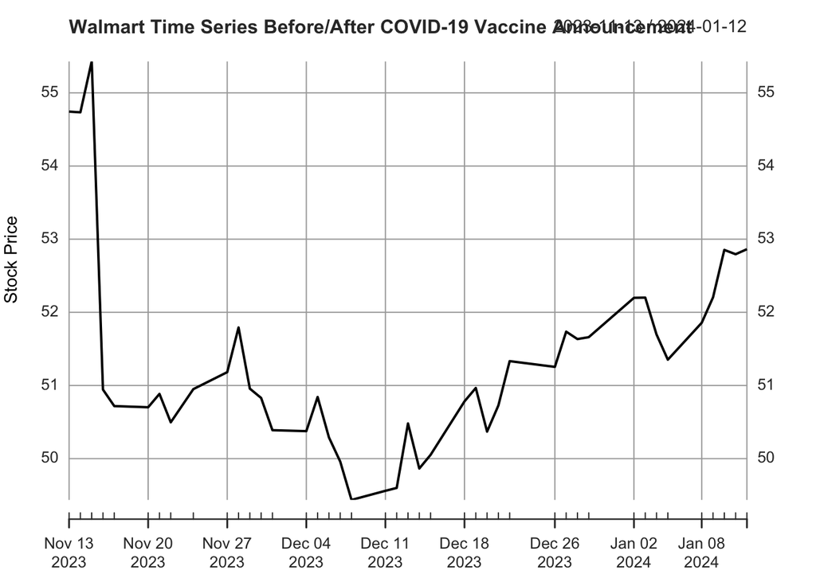

```r
##Walmart
wmt_data<-tq_get("WMT",get="stock.prices",complete_cases=TRUE,from="2023-11-13",to="2024-01-13")
xts_wmt<-xts(wmt_data$adjusted,order.by=tsla_data$date)
plot(xts_wmt,main="Walmart Time Series Before/After COVID-19 Vaccine Announcement",xlab="Date",ylab="Stock Price")
```

```r
wmt_data
```

```
## # A tibble: 42 × 8
##    symbol date        open  high   low close   volume adjusted
##    <chr>  <date>     <dbl> <dbl> <dbl> <dbl>    <dbl>    <dbl>
##  1 WMT    2023-11-13  55.5  56.0  55.3  55.9 15408900     54.7
##  2 WMT    2023-11-14  56.1  56.4  55.8  55.9 19792500     54.7
##  3 WMT    2023-11-15  56.1  56.6  55.8  56.6 35769900     55.4
##  4 WMT    2023-11-16  52.9  53.2  51.8  52.0 97658700     50.9
##  5 WMT    2023-11-17  52.0  52.5  51.7  51.8 42487800     50.7
##  6 WMT    2023-11-20  51.8  52.0  51.7  51.8 26663100     50.7
##  7 WMT    2023-11-21  51.8  52.3  51.4  52.0 29382300     50.9
##  8 WMT    2023-11-22  51.9  52.0  51.5  51.6 26416500     50.5
##  9 WMT    2023-11-24  51.7  52.0  51.6  52.0 13975200     51.0
## 10 WMT    2023-11-27  52.0  52.5  52.0  52.3 23393700     51.2
## # ℹ 32 more rows
```

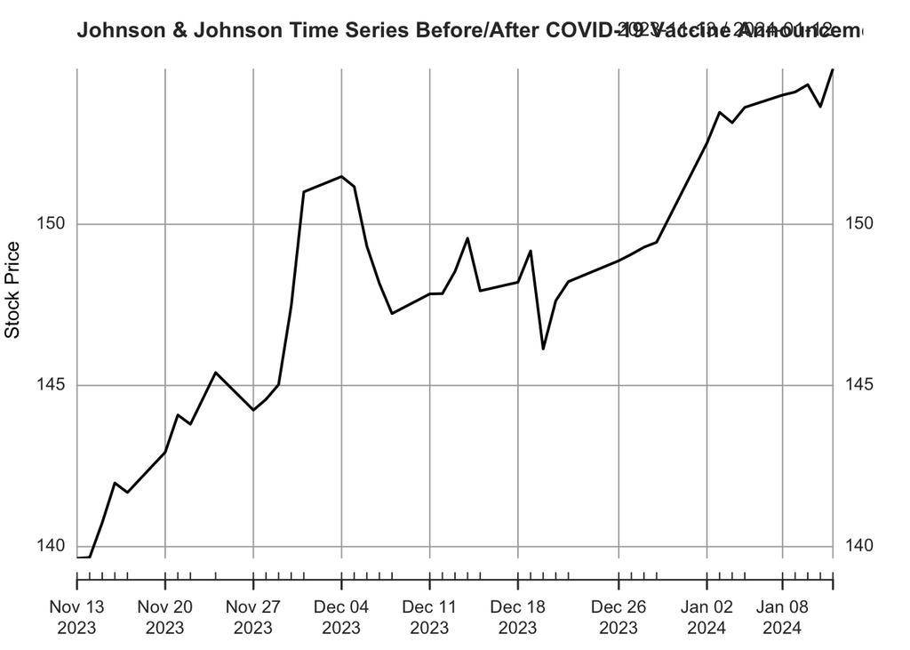

```r
##Johnson & Johnson
jnj_data<-tq_get("JNJ",get="stock.prices",complete_cases=TRUE,from="2023-11-13",to="2024-01-13")
xts_jnj<-xts(jnj_data$adjusted,order.by=tsla_data$date)
plot(xts_jnj,main="Johnson & Johnson Time Series Before/After COVID-19 Vaccine Announcement",xlab="Date",ylab="Stock Price")
```

```r
jnj_data
```

```
## # A tibble: 42 × 8
##    symbol date        open  high   low close  volume adjusted
##    <chr>  <date>     <dbl> <dbl> <dbl> <dbl>   <dbl>    <dbl>
##  1 JNJ    2023-11-13  147.  148.  147.  148. 5889300     140.
##  2 JNJ    2023-11-14  148.  149.  147.  148. 6713600     140.
##  3 JNJ    2023-11-15  147.  149.  147.  149. 6729100     141.
##  4 JNJ    2023-11-16  150.  150.  149.  150. 6875600     142.
##  5 JNJ    2023-11-17  151.  151.  149.  150. 7023300     142.
##  6 JNJ    2023-11-20  148.  150.  148.  150. 8851700     143.
##  7 JNJ    2023-11-21  150.  151.  150.  151. 5916300     144.
##  8 JNJ    2023-11-22  152.  152.  150.  151. 4633500     144.
##  9 JNJ    2023-11-24  151.  153.  151.  152. 3351400     145.
## 10 JNJ    2023-11-27  152.  152.  151.  151. 6449700     144.
## # ℹ 32 more rows
```

## Analysis of Time Series’ for Federal Reserve Interest Rate Hold December 13, 2023

Generally, all stocks experienced higher prices after the interest rate hold compared to before it. This observation makes sense as the Federal Reserve’s decision to hold interest rates may indicate that the inflation target is being reached. Lower interest rates will encourage more borrowing of money, which gives consumers more spending power. As a result, companies have more opportunities to make more profit. When the Federal Reserve first began raising interest rates in 2022, its incentive was to counter inflation. By holding interest rates, the Federal Reserve may be closer to reaching its targets, thus being able to have a calmer approach moving forward. Indications of an improving economy and giving consumers more spending power will ease the uncertainty on markets, allowing for their valuations to improve. Tesla was the only stock to face declining prices one month following the interest rate hold. This may be attributed to the company missing its expected earnings and price cuts due to increased competition from China. As such, the company still faces profit risks despite the Federal Reserve’s decision.

## Cross Validation for Time Series Trend Decomposition for Federal Reserve Interest Rate Hold December 13, 2023

```r
set.seed(100)

##Nvidia
nvda_train<-trainControl(method="timeslice",initialWindow=33,horizon=5)
nvda_grid_vals<-expand.grid(span=seq(from=0.1,to=0.9,by=0.01),degree=1)
nvda_data$date_times<-as.numeric(nvda_data$date)
nvda_cv<-suppressWarnings(train(adjusted~date_times,data=nvda_data,method="gamLoess",tuneGrid=nvda_grid_vals,trControl=nvda_train))
nvda_optimal_span<-nvda_cv$results|>slice_min(RMSE,with_ties=FALSE)|>pull(span)

##Amazon
amzn_train<-trainControl(method="timeslice",initialWindow=33,horizon=5)
amzn_grid_vals<-expand.grid(span=seq(from=0.1,to=0.9,by=0.01),degree=1)
amzn_data$date_times<-as.numeric(amzn_data$date)
amzn_cv<-suppressWarnings(train(adjusted~date_times,data=amzn_data,method="gamLoess",tuneGrid=amzn_grid_vals,trControl=amzn_train))
amzn_optimal_span<-amzn_cv$results|>slice_min(RMSE,with_ties=FALSE)|>pull(span)

##Berkshire Hathaway
brkb_train<-trainControl(method="timeslice",initialWindow=33,horizon=5)
brkb_grid_vals<-expand.grid(span=seq(from=0.1,to=0.9,by=0.01),degree=1)
brkb_data$date_times<-as.numeric(brkb_data$date)
brkb_cv<-suppressWarnings(train(adjusted~date_times,data=brkb_data,method="gamLoess",tuneGrid=brkb_grid_vals,trControl=brkb_train))
brkb_optimal_span<-brkb_cv$results|>slice_min(RMSE,with_ties=FALSE)|>pull(span)

##Tesla
tsla_train<-trainControl(method="timeslice",initialWindow=33,horizon=5)
tsla_grid_vals<-expand.grid(span=seq(from=0.1,to=0.9,by=0.01),degree=1)
tsla_data$date_times<-as.numeric(tsla_data$date)
tsla_cv<-suppressWarnings(train(adjusted~date_times,data=tsla_data,method="gamLoess",tuneGrid=tsla_grid_vals,trControl=tsla_train))
tsla_optimal_span<-tsla_cv$results|>slice_min(RMSE,with_ties=FALSE)|>pull(span)

##Walmart
wmt_train<-trainControl(method="timeslice",initialWindow=33,horizon=5)
wmt_grid_vals<-expand.grid(span=seq(from=0.1,to=0.9,by=0.01),degree=1)
wmt_data$date_times<-as.numeric(wmt_data$date)
wmt_cv<-suppressWarnings(train(adjusted~date_times,data=wmt_data,method="gamLoess",tuneGrid=wmt_grid_vals,trControl=wmt_train))
wmt_optimal_span<-wmt_cv$results|>slice_min(RMSE,with_ties=FALSE)|>pull(span)

##Johnson & Johnson
jnj_train<-trainControl(method="timeslice",initialWindow=33,horizon=5)
jnj_grid_vals<-expand.grid(span=seq(from=0.1,to=0.9,by=0.01),degree=1)
jnj_data$date_times<-as.numeric(jnj_data$date)
jnj_cv<-suppressWarnings(train(adjusted~date_times,data=jnj_data,method="gamLoess",tuneGrid=jnj_grid_vals,trControl=jnj_train))
jnj_optimal_span<-jnj_cv$results|>slice_min(RMSE,with_ties=FALSE)|>pull(span)
nvda_optimal_span
```

```
## [1] 0.88
```

```r
amzn_optimal_span
```

```
## [1] 0.4
```

```r
brkb_optimal_span
```

```
## [1] 0.31
```

```r
tsla_optimal_span
```

```
## [1] 0.31
```

```r
wmt_optimal_span
```

```
## [1] 0.82
```

```r
jnj_optimal_span
```

```
## [1] 0.37
```

## Time Series Decomposition (Trend & Residual)

Trend and Residual decompositions are created for the Time Series for the Federal Reserve interest rate hold of the 6 S&P 500 stocks using the optimal span calculated for each stock. Seasonal decompositions were not included as such decision does not occur on seasonal intervals.

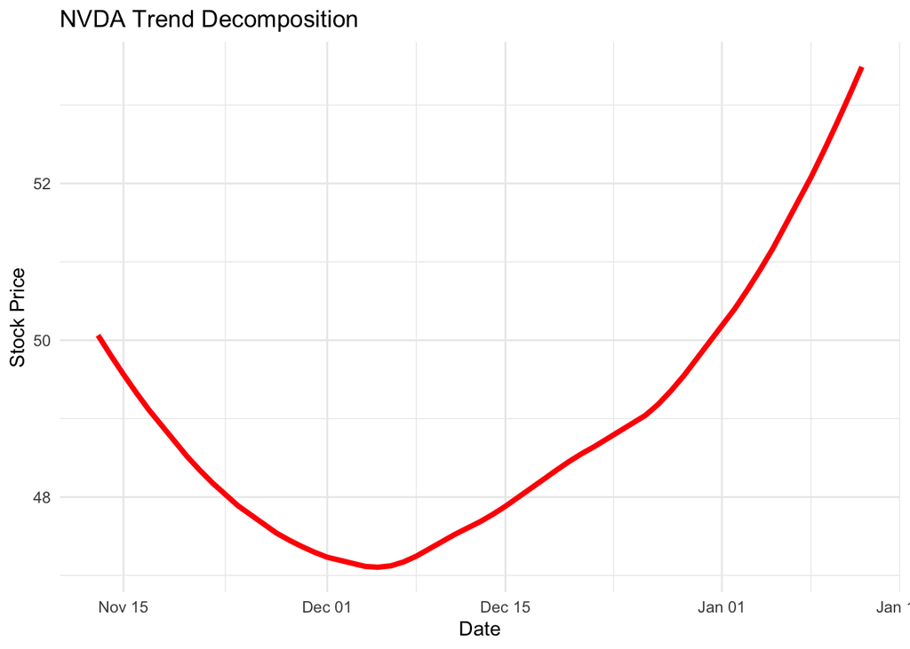

```r
##Nvidia
loess_nvda<-loess(adjusted~as.numeric(date),data=nvda_data,span=nvda_optimal_span)
smooth_nvda<-predict(loess_nvda)
trend_decomp_nvda_plot<-nvda_data|>ggplot(aes(x=date))+geom_line(aes(y=smooth_nvda),color="red",linewidth=1.4)+labs(title="NVDA Trend Decomposition",x="Date",y="Stock Price")+theme_minimal()
trend_decomp_nvda_plot
```

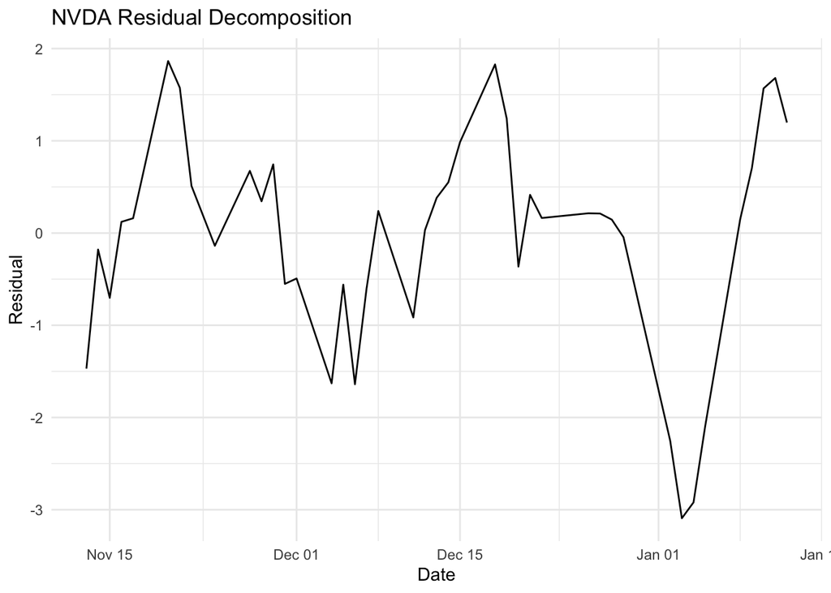

```r
nvda_data$residual_decomp<-residuals(loess_nvda)
residual_decomp_nvda_plot<-nvda_data|>ggplot(aes(x=date,y=residual_decomp))+geom_line()+labs(title="NVDA Residual Decomposition",x="Date",y="Residual")+theme_minimal()
residual_decomp_nvda_plot
```

```r
nvda_data
```

```
## # A tibble: 42 × 10
##    symbol date        open  high   low close    volume adjusted date_times
##    <chr>  <date>     <dbl> <dbl> <dbl> <dbl>     <dbl>    <dbl>      <dbl>
##  1 NVDA   2023-11-13  48.3  49.1  48.1  48.6 384136000     48.6      19674
##  2 NVDA   2023-11-14  49.7  49.8  49.0  49.7 416954000     49.6      19675
##  3 NVDA   2023-11-15  49.9  50.0  48.2  48.9 475497000     48.9      19676
##  4 NVDA   2023-11-16  48.7  49.5  48.3  49.5 339756000     49.5      19677
##  5 NVDA   2023-11-17  49.5  49.7  49.0  49.3 325205000     49.3      19678
##  6 NVDA   2023-11-20  49.3  50.5  49.2  50.4 414120000     50.4      19681
##  7 NVDA   2023-11-21  50.1  50.5  49.2  49.9 565747000     49.9      19682
##  8 NVDA   2023-11-22  49.9  50.3  47.7  48.7 899420000     48.7      19683
##  9 NVDA   2023-11-24  48.5  48.9  47.7  47.8 294645000     47.8      19685
## 10 NVDA   2023-11-27  47.8  48.5  47.7  48.2 395662000     48.2      19688
## # ℹ 32 more rows
## # ℹ 1 more variable: residual_decomp <dbl>
```

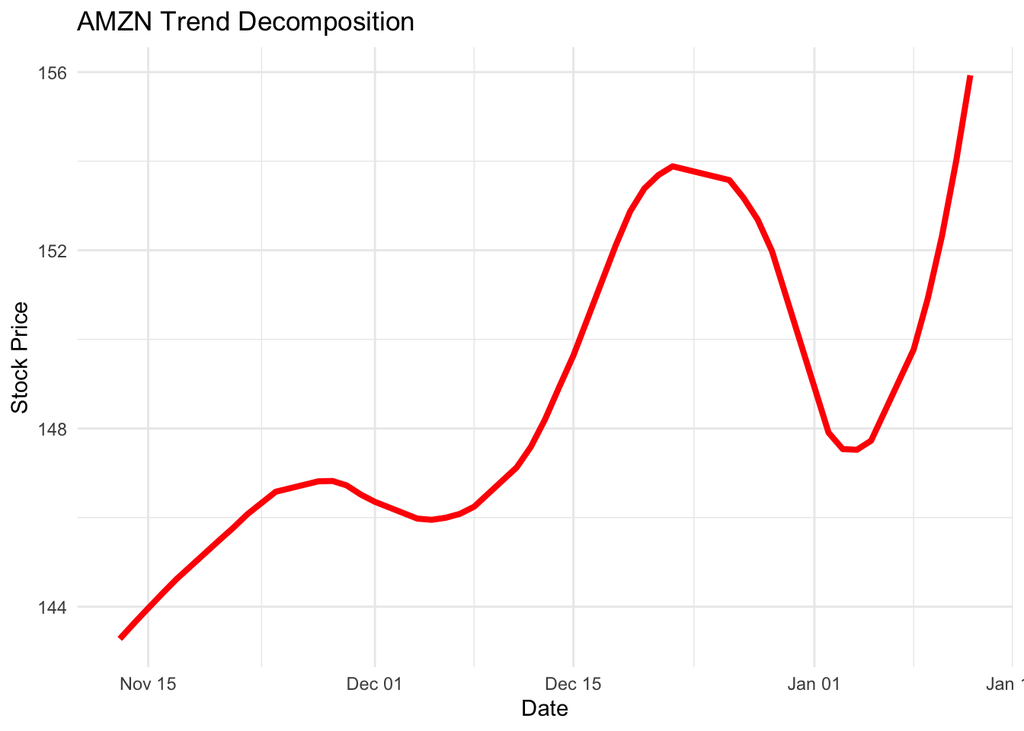

```r
##Amazon
loess_amzn<-loess(adjusted~as.numeric(date),data=amzn_data,span=amzn_optimal_span)
smooth_amzn<-predict(loess_amzn)
trend_decomp_amzn_plot<-amzn_data|>ggplot(aes(x=date))+geom_line(aes(y=smooth_amzn),color="red",linewidth=1.4)+labs(title="AMZN Trend Decomposition",x="Date",y="Stock Price")+theme_minimal()
trend_decomp_amzn_plot
```

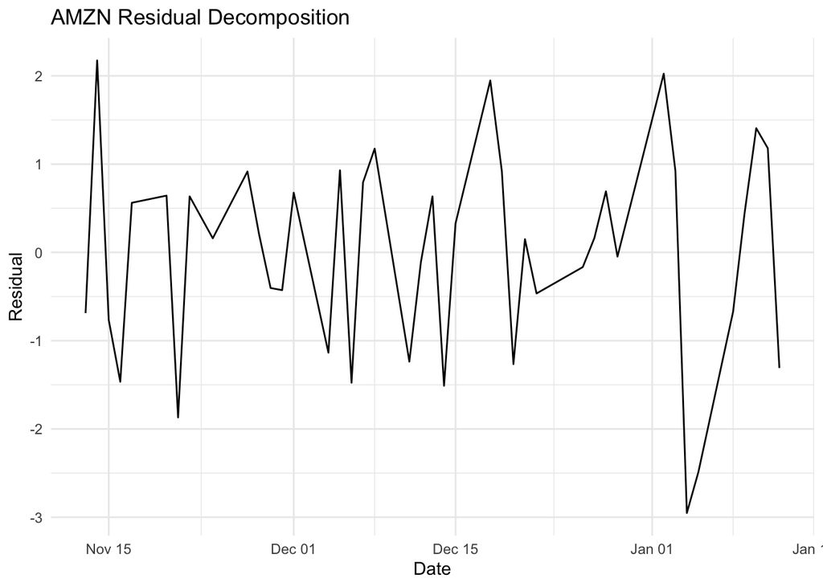

```r
amzn_data$residual_decomp<-residuals(loess_amzn)
residual_decomp_amzn_plot<-amzn_data|>ggplot(aes(x=date,y=residual_decomp))+geom_line()+labs(title="AMZN Residual Decomposition",x="Date",y="Residual")+theme_minimal()
residual_decomp_amzn_plot
```

```r
amzn_data
```

```
## # A tibble: 42 × 10
##    symbol date        open  high   low close   volume adjusted date_times
##    <chr>  <date>     <dbl> <dbl> <dbl> <dbl>    <dbl>    <dbl>      <dbl>
##  1 AMZN   2023-11-13  142.  143.  141.  143. 35680600     143.      19674
##  2 AMZN   2023-11-14  145   147.  145.  146. 56674600     146.      19675
##  3 AMZN   2023-11-15  147.  147.  143.  143. 63875700     143.      19676
##  4 AMZN   2023-11-16  141.  143.  140.  143. 49653500     143.      19677
##  5 AMZN   2023-11-17  143.  145.  143.  145. 49636700     145.      19678
##  6 AMZN   2023-11-20  145.  147.  145.  146. 41951200     146.      19681
##  7 AMZN   2023-11-21  144.  144.  142.  144. 71226000     144.      19682
##  8 AMZN   2023-11-22  145.  148.  145.  147. 45669100     147.      19683
##  9 AMZN   2023-11-24  147.  147.  145.  147. 22378400     147.      19685
## 10 AMZN   2023-11-27  148.  149.  147.  148. 53762400     148.      19688
## # ℹ 32 more rows
## # ℹ 1 more variable: residual_decomp <dbl>
```

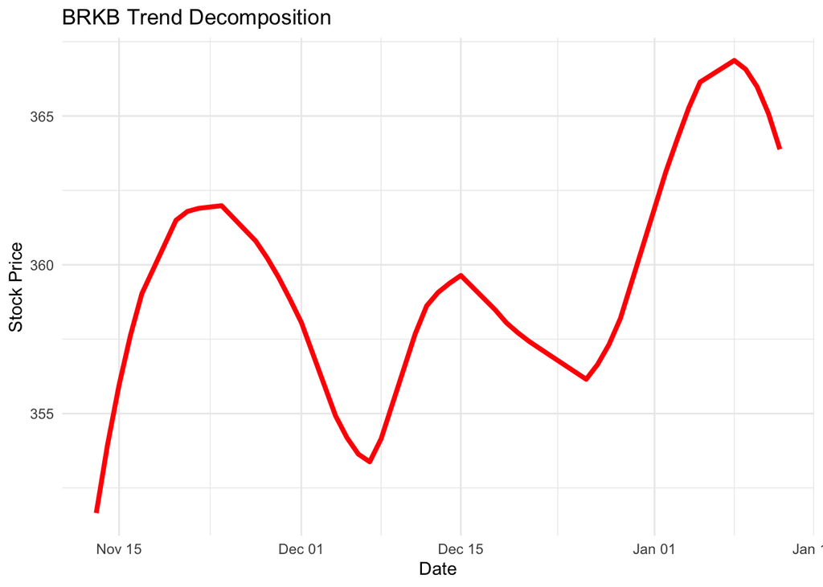

```r
##Berkshire Hathaway
loess_brkb<-loess(adjusted~as.numeric(date),data=brkb_data,span=brkb_optimal_span)
smooth_brkb<-predict(loess_brkb)
trend_decomp_brkb_plot<-brkb_data|>ggplot(aes(x=date))+geom_line(aes(y=smooth_brkb),color="red",linewidth=1.4)+labs(title="BRKB Trend Decomposition",x="Date",y="Stock Price")+theme_minimal()
trend_decomp_brkb_plot
```

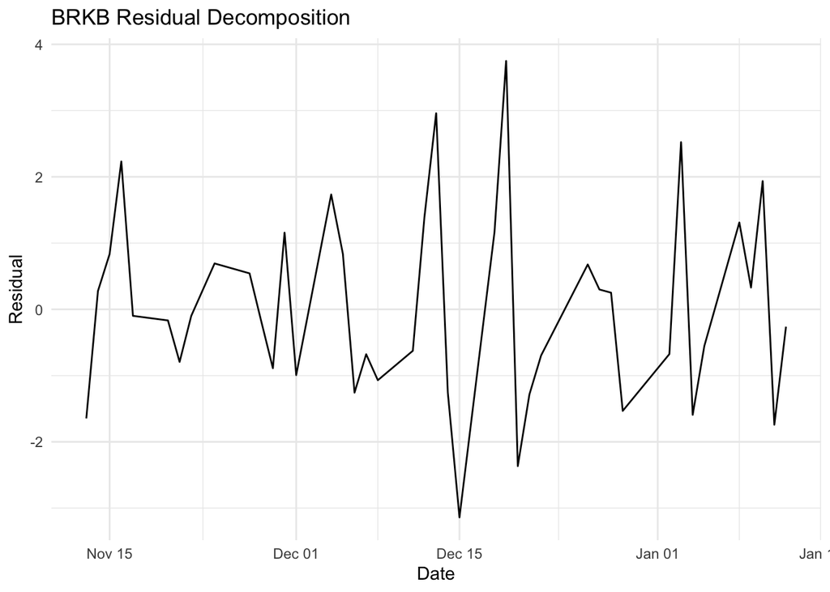

```r
brkb_data$residual_decomp<-residuals(loess_brkb)
residual_decomp_brkb_plot<-brkb_data|>ggplot(aes(x=date,y=residual_decomp))+geom_line()+labs(title="BRKB Residual Decomposition",x="Date",y="Residual")+theme_minimal()
residual_decomp_brkb_plot
```

```r
brkb_data
```

```
## # A tibble: 42 × 10
##    symbol date        open  high   low close  volume adjusted date_times
##    <chr>  <date>     <dbl> <dbl> <dbl> <dbl>   <dbl>    <dbl>      <dbl>
##  1 BRK-B  2023-11-13  350.  351.  349.  350. 2196200     350.      19674
##  2 BRK-B  2023-11-14  353.  356.  351.  354. 3387500     354.      19675
##  3 BRK-B  2023-11-15  355.  357.  354.  357. 3572900     357.      19676
##  4 BRK-B  2023-11-16  358.  360   357.  360. 2822500     360.      19677
##  5 BRK-B  2023-11-17  360.  361.  358.  359. 3260000     359.      19678
##  6 BRK-B  2023-11-20  359.  363.  358.  361. 3215300     361.      19681
##  7 BRK-B  2023-11-21  361.  363.  360.  361  2918800     361       19682
##  8 BRK-B  2023-11-22  362.  362.  360.  362. 2110200     362.      19683
##  9 BRK-B  2023-11-24  363.  363.  361.  363. 1282000     363.      19685
## 10 BRK-B  2023-11-27  363.  363.  360.  361. 2580300     361.      19688
## # ℹ 32 more rows
## # ℹ 1 more variable: residual_decomp <dbl>
```

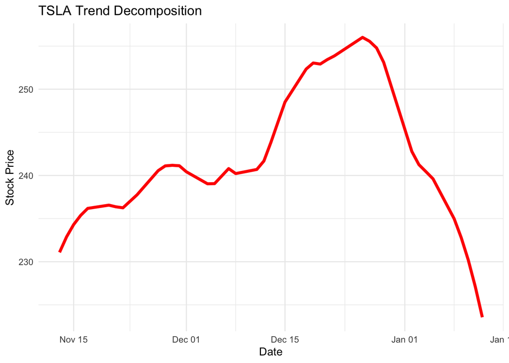

```r
##Tesla
loess_tsla<-loess(adjusted~as.numeric(date),data=tsla_data,span=tsla_optimal_span)
smooth_tsla<-predict(loess_tsla)
trend_decomp_tsla_plot<-tsla_data|>ggplot(aes(x=date))+geom_line(aes(y=smooth_tsla),color="red",linewidth=1.4)+labs(title="TSLA Trend Decomposition",x="Date",y="Stock Price")+theme_minimal()
trend_decomp_tsla_plot
```

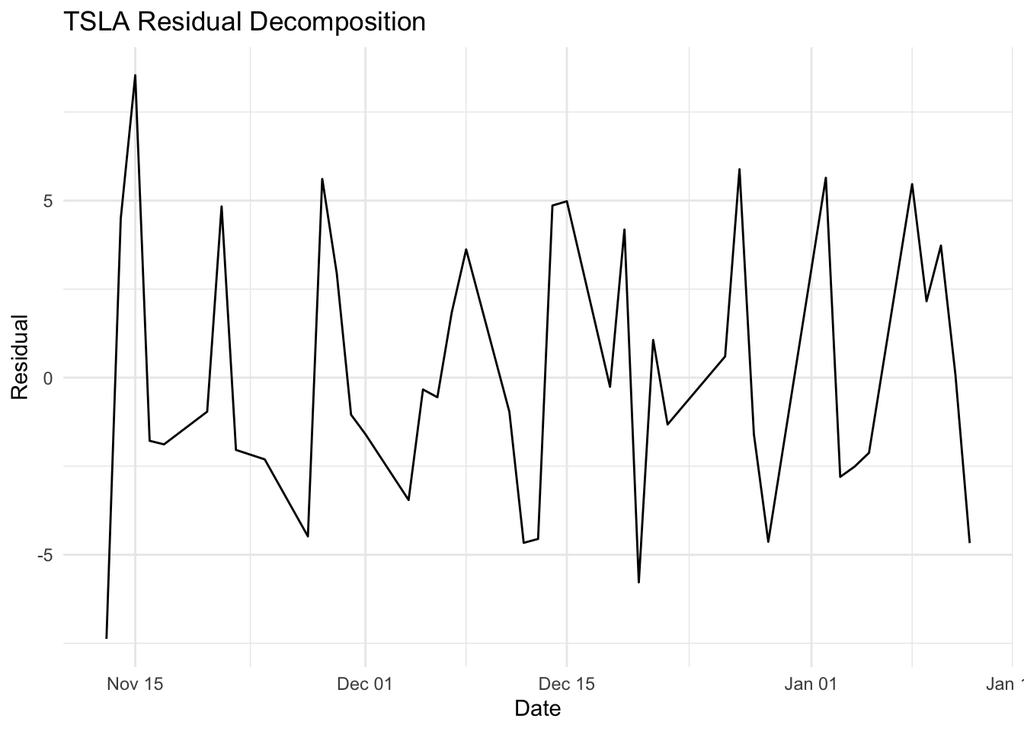

```r
tsla_data$residual_decomp<-residuals(loess_tsla)
residual_decomp_tsla_plot<-tsla_data|>ggplot(aes(x=date,y=residual_decomp))+geom_line()+labs(title="TSLA Residual Decomposition",x="Date",y="Residual")+theme_minimal()
residual_decomp_tsla_plot
```

```r
tsla_data
```

```
## # A tibble: 42 × 10
##    symbol date        open  high   low close    volume adjusted date_times
##    <chr>  <date>     <dbl> <dbl> <dbl> <dbl>     <dbl>    <dbl>      <dbl>
##  1 TSLA   2023-11-13  216.  225.  212.  224. 140447600     224.      19674
##  2 TSLA   2023-11-14  235.  238.  231.  237. 149771600     237.      19675
##  3 TSLA   2023-11-15  239.  247.  236.  243. 150354000     243.      19676
##  4 TSLA   2023-11-16  239.  241.  231.  234. 136816800     234.      19677
##  5 TSLA   2023-11-17  232   237.  227.  234. 142532800     234.      19678
##  6 TSLA   2023-11-20  234.  237.  231.  236. 116320100     236.      19681
##  7 TSLA   2023-11-21  235.  244.  233.  241. 122288000     241.      19682
##  8 TSLA   2023-11-22  242.  244.  231.  234. 117950600     234.      19683
##  9 TSLA   2023-11-24  234.  239.  232.  235.  65125200     235.      19685
## 10 TSLA   2023-11-27  237.  238.  232.  236. 112031800     236.      19688
## # ℹ 32 more rows
## # ℹ 1 more variable: residual_decomp <dbl>
```

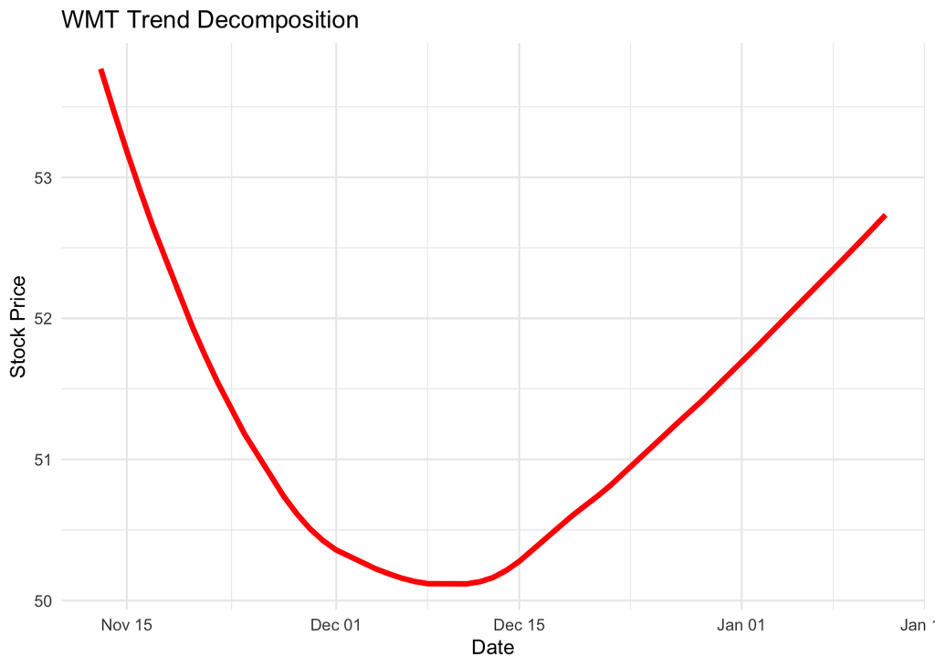

```r
##Walmart

loess_wmt<-loess(adjusted~as.numeric(date),data=wmt_data,span=wmt_optimal_span)
smooth_wmt<-predict(loess_wmt)
trend_decomp_wmt_plot<-wmt_data|>ggplot(aes(x=date))+geom_line(aes(y=smooth_wmt),color="red",linewidth=1.4)+labs(title="WMT Trend Decomposition",x="Date",y="Stock Price")+theme_minimal()
trend_decomp_wmt_plot
```

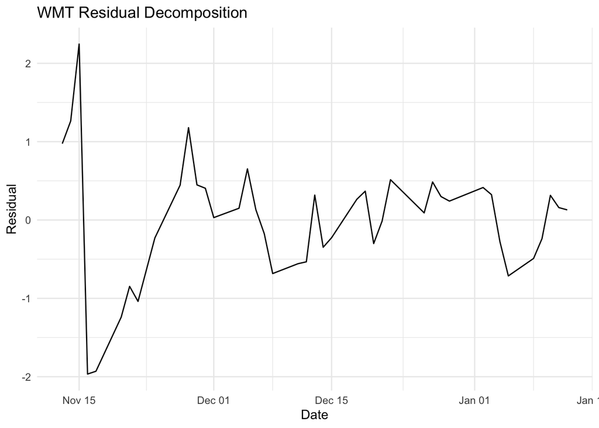

```r
wmt_data$residual_decomp<-residuals(loess_wmt)
residual_decomp_wmt_plot<-wmt_data|>ggplot(aes(x=date,y=residual_decomp))+geom_line()+labs(title="WMT Residual Decomposition",x="Date",y="Residual")+theme_minimal()
residual_decomp_wmt_plot
```

```r
wmt_data
```

```
## # A tibble: 42 × 10
##    symbol date        open  high   low close   volume adjusted date_times
##    <chr>  <date>     <dbl> <dbl> <dbl> <dbl>    <dbl>    <dbl>      <dbl>
##  1 WMT    2023-11-13  55.5  56.0  55.3  55.9 15408900     54.7      19674
##  2 WMT    2023-11-14  56.1  56.4  55.8  55.9 19792500     54.7      19675
##  3 WMT    2023-11-15  56.1  56.6  55.8  56.6 35769900     55.4      19676
##  4 WMT    2023-11-16  52.9  53.2  51.8  52.0 97658700     50.9      19677
##  5 WMT    2023-11-17  52.0  52.5  51.7  51.8 42487800     50.7      19678
##  6 WMT    2023-11-20  51.8  52.0  51.7  51.8 26663100     50.7      19681
##  7 WMT    2023-11-21  51.8  52.3  51.4  52.0 29382300     50.9      19682
##  8 WMT    2023-11-22  51.9  52.0  51.5  51.6 26416500     50.5      19683
##  9 WMT    2023-11-24  51.7  52.0  51.6  52.0 13975200     51.0      19685
## 10 WMT    2023-11-27  52.0  52.5  52.0  52.3 23393700     51.2      19688
## # ℹ 32 more rows
## # ℹ 1 more variable: residual_decomp <dbl>
```

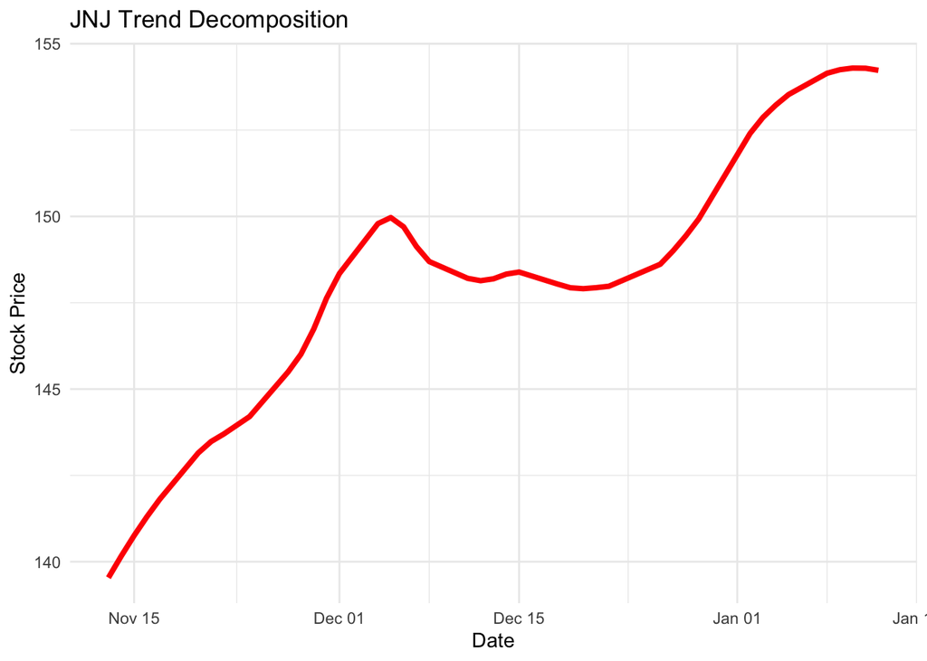

```r
##Johnson & Johnson

loess_jnj<-loess(adjusted~as.numeric(date),data=jnj_data,span=jnj_optimal_span)
smooth_jnj<-predict(loess_jnj)
trend_decomp_jnj_plot<-jnj_data|>ggplot(aes(x=date))+geom_line(aes(y=smooth_jnj),color="red",linewidth=1.4)+labs(title="JNJ Trend Decomposition",x="Date",y="Stock Price")+theme_minimal()
trend_decomp_jnj_plot
```

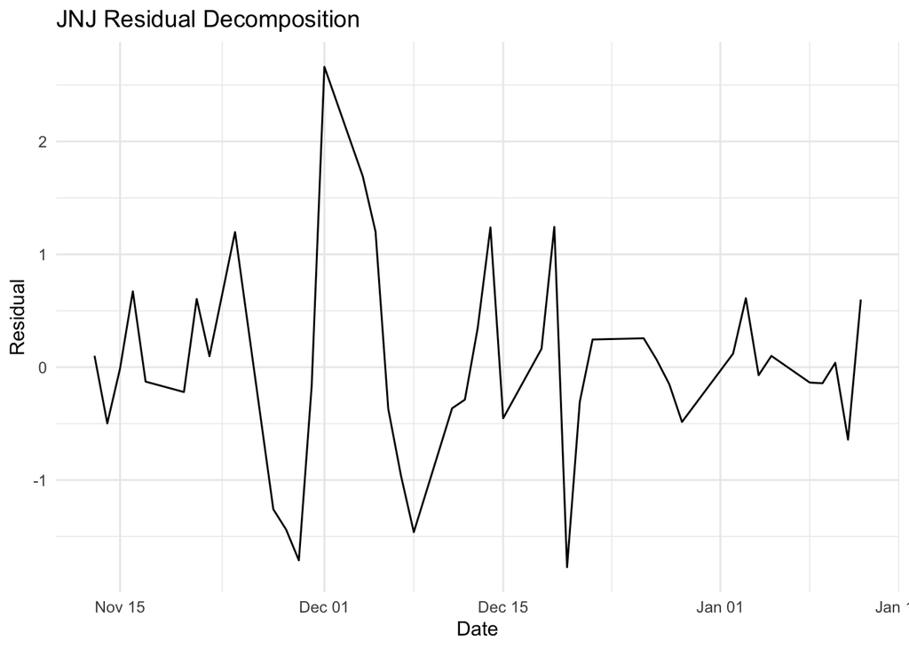

```r
jnj_data$residual_decomp<-residuals(loess_jnj)
residual_decomp_jnj_plot<-jnj_data|>ggplot(aes(x=date,y=residual_decomp))+geom_line()+labs(title="JNJ Residual Decomposition",x="Date",y="Residual")+theme_minimal()
residual_decomp_jnj_plot
```

```r
jnj_data
```

```
## # A tibble: 42 × 10
##    symbol date        open  high   low close  volume adjusted date_times
##    <chr>  <date>     <dbl> <dbl> <dbl> <dbl>   <dbl>    <dbl>      <dbl>
##  1 JNJ    2023-11-13  147.  148.  147.  148. 5889300     140.      19674
##  2 JNJ    2023-11-14  148.  149.  147.  148. 6713600     140.      19675
##  3 JNJ    2023-11-15  147.  149.  147.  149. 6729100     141.      19676
##  4 JNJ    2023-11-16  150.  150.  149.  150. 6875600     142.      19677
##  5 JNJ    2023-11-17  151.  151.  149.  150. 7023300     142.      19678
##  6 JNJ    2023-11-20  148.  150.  148.  150. 8851700     143.      19681
##  7 JNJ    2023-11-21  150.  151.  150.  151. 5916300     144.      19682
##  8 JNJ    2023-11-22  152.  152.  150.  151. 4633500     144.      19683
##  9 JNJ    2023-11-24  151.  153.  151.  152. 3351400     145.      19685
## 10 JNJ    2023-11-27  152.  152.  151.  151. 6449700     144.      19688
## # ℹ 32 more rows
## # ℹ 1 more variable: residual_decomp <dbl>
```

## Analysis of Trend and Residual Decompositions

As previously touched on in the analysis for the time series’, it is clearer based on the trends that Tesla is seeing a staunch decline in prices. Though Amazon also faced a decline in prices during early January of 2024, its prices still trend above the prices trended prior to the Federal Reserve decision. Excluding Tesla, all stocks are generally increasing in price following the decision. This may indicate that the markets are now beginning to recover from the inflationary/affordability crisis. According to Statista, the inflation rate peaked at 9.1% in June 2022 and fell to 3.4% in December 2023. These figures align exactly with the Federal Reserve’s decision making. On June 15, 2022, interest rates were raised with the highest magnitude in over 40 years, and in December 2023, interest rates are being held as inflation has cooled down by a lot. With lower inflation, consumers will be less worried about affordability, which gives more profit opportunity to markets. Nvidia, Amazon, Berkshire Hathaway, and Tesla experienced more noisy residuals with frequent large swings. This observation may be attributed to their time series, which exhibited a lot of alternations between increasing and decreasing in stock prices, even though Nvidia, Amazon, and Berkshire Hathaway were able to trend upwards in price.

## Returns, Mean Returns, Volatility, and 3-Day Rolling Volatility

Calculating returns, mean returns, volatility, and 3-day rolling volatility to compare for data analysis. For each stock, the returns, mean returns, and volatility are calculated prior to and after the Federal Reserve announcement to observe differences. The 3-day rolling volatility is calculated using the data from the previous 2 trading days and the current day, which means the first 3-day rolling volatility occurs on the third trading day.

```r
###Returns, Mean Returns

##Nvidia
nvda_data<-nvda_data|>mutate(returns=(adjusted-lag(adjusted))/lag(adjusted),mean_returns=if_else(is.na(returns),NA_real_,cummean(replace_na(returns,0))))
nvda_mean_return_pre<-nvda_data|>filter(date<="2023-12-12",date>="2023-11-13")|>summarise(nvda_mean_return_pre = mean(returns,na.rm=TRUE))
nvda_mean_return_post<-nvda_data|>filter(date>="2023-12-14",date<="2024-01-13")|>summarise(nvda_mean_return_post = mean(returns,na.rm=TRUE))

##Amazon
amzn_data<-amzn_data|>mutate(returns=(adjusted-lag(adjusted))/lag(adjusted),mean_returns=if_else(is.na(returns),NA_real_,cummean(replace_na(returns,0))))
amzn_mean_return_pre<-amzn_data|>filter(date<="2023-12-12",date>="2023-11-13")|>summarise(amzn_mean_return_pre = mean(returns,na.rm=TRUE))
amzn_mean_return_post<-amzn_data|>filter(date>="2023-12-14",date<="2024-01-13")|>summarise(amzn_mean_return_post = mean(returns,na.rm=TRUE))

##Berkshire Hathaway
brkb_data<-brkb_data|>mutate(returns=(adjusted-lag(adjusted))/lag(adjusted),mean_returns=if_else(is.na(returns),NA_real_,cummean(replace_na(returns,0))))
brkb_mean_return_pre<-brkb_data|>filter(date<="2023-12-12",date>="2023-11-13")|>summarise(brkb_mean_return_pre=mean(returns,na.rm=TRUE))
brkb_mean_return_post<-brkb_data|>filter(date>="2023-12-14",date<="2024-01-13")|>summarise(brkb_mean_return_post=mean(returns,na.rm=TRUE))

##Tesla
tsla_data<-tsla_data|>mutate(returns=(adjusted-lag(adjusted))/lag(adjusted),mean_returns=if_else(is.na(returns),NA_real_,cummean(replace_na(returns,0))))
tsla_mean_return_pre<-tsla_data|>filter(date<="2023-12-12",date>="2023-11-13")|>summarise(tsla_mean_return_pre=mean(returns,na.rm=TRUE))
tsla_mean_return_post<-tsla_data|>filter(date>="2023-12-14",date<="2024-01-13")|>summarise(tsla_mean_return_post=mean(returns,na.rm=TRUE))

##Walmart
wmt_data<-wmt_data|>mutate(returns=(adjusted-lag(adjusted))/lag(adjusted),mean_returns=if_else(is.na(returns),NA_real_,cummean(replace_na(returns,0))))
wmt_mean_return_pre<-wmt_data|>filter(date<="2023-12-12",date>="2023-11-13")|>summarise(wmt_mean_return_pre=mean(returns,na.rm=TRUE))
wmt_mean_return_post<-wmt_data|>filter(date>="2023-12-14",date<="2024-01-13")|>summarise(wmt_mean_return_post=mean(returns,na.rm=TRUE))

##Johnson & Johnson
jnj_data<-jnj_data|>mutate(returns=(adjusted-lag(adjusted))/lag(adjusted),mean_returns=if_else(is.na(returns),NA_real_,cummean(replace_na(returns,0))))
jnj_mean_return_pre<-jnj_data|>filter(date<="2023-12-12",date>="2023-11-13")|>summarise(jnj_mean_return_pre=mean(returns,na.rm=TRUE))
jnj_mean_return_post<-jnj_data|>filter(date>="2023-12-14",date<="2024-01-13")|>summarise(jnj_mean_return_post=mean(returns,na.rm=TRUE))

###Volatility

##Nvidia
nvda_volatility<-nvda_data|>summarise(nvda_volatility=sd(returns,na.rm=TRUE))
nvda_volatility_pre<-nvda_data|>filter(date<="2023-12-12",date>="2023-11-13")|>summarise(nvda_volatility_pre=sd(returns,na.rm=TRUE))
nvda_volatility_post<-nvda_data|>filter(date>="2023-12-14",date<="2024-01-13")|>summarise(nvda_volatility_post=sd(returns,na.rm=TRUE))

##Amazon
amzn_volatility<-amzn_data|>summarise(amzn_volatility=sd(returns,na.rm=TRUE))
amzn_volatility_pre<-amzn_data|>filter(date<="2023-12-12",date>="2023-11-13")|>summarise(amzn_volatility_pre=sd(returns,na.rm=TRUE))
amzn_volatility_post<-amzn_data|>filter(date>="2023-12-14",date<="2024-01-13")|>summarise(amzn_volatility_post=sd(returns,na.rm=TRUE))

##Berkshire Hathaway
brkb_volatility<-brkb_data|>summarise(brkb_volatility=sd(returns,na.rm=TRUE))
brkb_volatility_pre<-brkb_data|>filter(date<="2023-12-12",date>="2023-11-13")|>summarise(brkb_volatility_pre=sd(returns,na.rm=TRUE))
brkb_volatility_post<-brkb_data|>filter(date>="2023-12-14",date<="2024-01-13")|>summarise(brkb_volatility_post=sd(returns,na.rm=TRUE))

##Tesla
tsla_volatility<-tsla_data|>summarise(volatility=sd(returns,na.rm=TRUE))
tsla_volatility_pre<-tsla_data|>filter(date<="2023-12-12",date>="2023-11-13")|>summarise(tsla_volatility_pre=sd(returns,na.rm=TRUE))
tsla_volatility_post<-tsla_data|>filter(date>="2023-12-14",date<="2024-01-13")|>summarise(tsla_volatility_post=sd(returns,na.rm=TRUE))

##Walmart
wmt_volatility<-wmt_data|>summarise(volatility=sd(returns,na.rm=TRUE))
wmt_volatility_pre<-wmt_data|>filter(date<="2023-12-12",date>="2023-11-13")|>summarise(wmt_volatility_pre=sd(returns,na.rm=TRUE))
wmt_volatility_post<-wmt_data|>filter(date>="2023-12-14",date<="2024-01-13")|>summarise(wmt_volatility_post=sd(returns,na.rm=TRUE))

##Johnson & Johnson
jnj_volatility<-jnj_data|>summarise(volatility=sd(returns,na.rm=TRUE))
jnj_volatility_pre<-jnj_data|>filter(date<="2023-12-12",date>="2023-11-13")|>summarise(jnj_volatility_pre=sd(returns,na.rm=TRUE))
jnj_volatility_post<-jnj_data|>filter(date>="2023-12-14",date<="2024-01-13")|>summarise(jnj_volatility_post=sd(returns,na.rm=TRUE))

###3-Day Rolling Volatility

##Nvidia
nvda_data<-nvda_data|>mutate(three_day_rolling_volatility=rollapply(returns,width=3,FUN=sd,na.rm=TRUE,fill=NA,align="right"))
nvda_data
```

```
## # A tibble: 42 × 13
##    symbol date        open  high   low close    volume adjusted date_times
##    <chr>  <date>     <dbl> <dbl> <dbl> <dbl>     <dbl>    <dbl>      <dbl>
##  1 NVDA   2023-11-13  48.3  49.1  48.1  48.6 384136000     48.6      19674
##  2 NVDA   2023-11-14  49.7  49.8  49.0  49.7 416954000     49.6      19675
##  3 NVDA   2023-11-15  49.9  50.0  48.2  48.9 475497000     48.9      19676
##  4 NVDA   2023-11-16  48.7  49.5  48.3  49.5 339756000     49.5      19677
##  5 NVDA   2023-11-17  49.5  49.7  49.0  49.3 325205000     49.3      19678
##  6 NVDA   2023-11-20  49.3  50.5  49.2  50.4 414120000     50.4      19681
##  7 NVDA   2023-11-21  50.1  50.5  49.2  49.9 565747000     49.9      19682
##  8 NVDA   2023-11-22  49.9  50.3  47.7  48.7 899420000     48.7      19683
##  9 NVDA   2023-11-24  48.5  48.9  47.7  47.8 294645000     47.8      19685
## 10 NVDA   2023-11-27  47.8  48.5  47.7  48.2 395662000     48.2      19688
## # ℹ 32 more rows
## # ℹ 4 more variables: residual_decomp <dbl>, returns <dbl>, mean_returns <dbl>,
## #   three_day_rolling_volatility <dbl>
```

```r
##Amazon
amzn_data<-amzn_data|>mutate(three_day_rolling_volatility=rollapply(returns,width=3,FUN=sd,na.rm=TRUE,fill=NA,align="right"))
amzn_data
```

```
## # A tibble: 42 × 13
##    symbol date        open  high   low close   volume adjusted date_times
##    <chr>  <date>     <dbl> <dbl> <dbl> <dbl>    <dbl>    <dbl>      <dbl>
##  1 AMZN   2023-11-13  142.  143.  141.  143. 35680600     143.      19674
##  2 AMZN   2023-11-14  145   147.  145.  146. 56674600     146.      19675
##  3 AMZN   2023-11-15  147.  147.  143.  143. 63875700     143.      19676
##  4 AMZN   2023-11-16  141.  143.  140.  143. 49653500     143.      19677
##  5 AMZN   2023-11-17  143.  145.  143.  145. 49636700     145.      19678
##  6 AMZN   2023-11-20  145.  147.  145.  146. 41951200     146.      19681
##  7 AMZN   2023-11-21  144.  144.  142.  144. 71226000     144.      19682
##  8 AMZN   2023-11-22  145.  148.  145.  147. 45669100     147.      19683
##  9 AMZN   2023-11-24  147.  147.  145.  147. 22378400     147.      19685
## 10 AMZN   2023-11-27  148.  149.  147.  148. 53762400     148.      19688
## # ℹ 32 more rows
## # ℹ 4 more variables: residual_decomp <dbl>, returns <dbl>, mean_returns <dbl>,
## #   three_day_rolling_volatility <dbl>
```

```r
##Berkshire Hathaway
brkb_data<-brkb_data|>mutate(three_day_rolling_volatility=rollapply(returns,width=3,FUN=sd,na.rm=TRUE,fill=NA,align="right"))
brkb_data
```

```
## # A tibble: 42 × 13
##    symbol date        open  high   low close  volume adjusted date_times
##    <chr>  <date>     <dbl> <dbl> <dbl> <dbl>   <dbl>    <dbl>      <dbl>
##  1 BRK-B  2023-11-13  350.  351.  349.  350. 2196200     350.      19674
##  2 BRK-B  2023-11-14  353.  356.  351.  354. 3387500     354.      19675
##  3 BRK-B  2023-11-15  355.  357.  354.  357. 3572900     357.      19676
##  4 BRK-B  2023-11-16  358.  360   357.  360. 2822500     360.      19677
##  5 BRK-B  2023-11-17  360.  361.  358.  359. 3260000     359.      19678
##  6 BRK-B  2023-11-20  359.  363.  358.  361. 3215300     361.      19681
##  7 BRK-B  2023-11-21  361.  363.  360.  361  2918800     361       19682
##  8 BRK-B  2023-11-22  362.  362.  360.  362. 2110200     362.      19683
##  9 BRK-B  2023-11-24  363.  363.  361.  363. 1282000     363.      19685
## 10 BRK-B  2023-11-27  363.  363.  360.  361. 2580300     361.      19688
## # ℹ 32 more rows
## # ℹ 4 more variables: residual_decomp <dbl>, returns <dbl>, mean_returns <dbl>,
## #   three_day_rolling_volatility <dbl>
```

```r
##Tesla
tsla_data<-tsla_data|>mutate(three_day_rolling_volatility=rollapply(returns,width=3,FUN=sd,na.rm=TRUE,fill=NA,align="right"))
tsla_data
```

```
## # A tibble: 42 × 13
##    symbol date        open  high   low close    volume adjusted date_times
##    <chr>  <date>     <dbl> <dbl> <dbl> <dbl>     <dbl>    <dbl>      <dbl>
##  1 TSLA   2023-11-13  216.  225.  212.  224. 140447600     224.      19674
##  2 TSLA   2023-11-14  235.  238.  231.  237. 149771600     237.      19675
##  3 TSLA   2023-11-15  239.  247.  236.  243. 150354000     243.      19676
##  4 TSLA   2023-11-16  239.  241.  231.  234. 136816800     234.      19677
##  5 TSLA   2023-11-17  232   237.  227.  234. 142532800     234.      19678
##  6 TSLA   2023-11-20  234.  237.  231.  236. 116320100     236.      19681
##  7 TSLA   2023-11-21  235.  244.  233.  241. 122288000     241.      19682
##  8 TSLA   2023-11-22  242.  244.  231.  234. 117950600     234.      19683
##  9 TSLA   2023-11-24  234.  239.  232.  235.  65125200     235.      19685
## 10 TSLA   2023-11-27  237.  238.  232.  236. 112031800     236.      19688
## # ℹ 32 more rows
## # ℹ 4 more variables: residual_decomp <dbl>, returns <dbl>, mean_returns <dbl>,
## #   three_day_rolling_volatility <dbl>
```

```r
##Walmart
wmt_data<-wmt_data|>mutate(three_day_rolling_volatility=rollapply(returns,width=3,FUN=sd,na.rm=TRUE,fill=NA,align="right"))
wmt_data
```

```
## # A tibble: 42 × 13
##    symbol date        open  high   low close   volume adjusted date_times
##    <chr>  <date>     <dbl> <dbl> <dbl> <dbl>    <dbl>    <dbl>      <dbl>
##  1 WMT    2023-11-13  55.5  56.0  55.3  55.9 15408900     54.7      19674
##  2 WMT    2023-11-14  56.1  56.4  55.8  55.9 19792500     54.7      19675
##  3 WMT    2023-11-15  56.1  56.6  55.8  56.6 35769900     55.4      19676
##  4 WMT    2023-11-16  52.9  53.2  51.8  52.0 97658700     50.9      19677
##  5 WMT    2023-11-17  52.0  52.5  51.7  51.8 42487800     50.7      19678
##  6 WMT    2023-11-20  51.8  52.0  51.7  51.8 26663100     50.7      19681
##  7 WMT    2023-11-21  51.8  52.3  51.4  52.0 29382300     50.9      19682
##  8 WMT    2023-11-22  51.9  52.0  51.5  51.6 26416500     50.5      19683
##  9 WMT    2023-11-24  51.7  52.0  51.6  52.0 13975200     51.0      19685
## 10 WMT    2023-11-27  52.0  52.5  52.0  52.3 23393700     51.2      19688
## # ℹ 32 more rows
## # ℹ 4 more variables: residual_decomp <dbl>, returns <dbl>, mean_returns <dbl>,
## #   three_day_rolling_volatility <dbl>
```

```r
##Johnson & Johnson
jnj_data<-jnj_data|>mutate(three_day_rolling_volatility=rollapply(returns,width=3,FUN=sd,na.rm=TRUE,fill=NA,align="right"))
jnj_data
```

```
## # A tibble: 42 × 13
##    symbol date        open  high   low close  volume adjusted date_times
##    <chr>  <date>     <dbl> <dbl> <dbl> <dbl>   <dbl>    <dbl>      <dbl>
##  1 JNJ    2023-11-13  147.  148.  147.  148. 5889300     140.      19674
##  2 JNJ    2023-11-14  148.  149.  147.  148. 6713600     140.      19675
##  3 JNJ    2023-11-15  147.  149.  147.  149. 6729100     141.      19676
##  4 JNJ    2023-11-16  150.  150.  149.  150. 6875600     142.      19677
##  5 JNJ    2023-11-17  151.  151.  149.  150. 7023300     142.      19678
##  6 JNJ    2023-11-20  148.  150.  148.  150. 8851700     143.      19681
##  7 JNJ    2023-11-21  150.  151.  150.  151. 5916300     144.      19682
##  8 JNJ    2023-11-22  152.  152.  150.  151. 4633500     144.      19683
##  9 JNJ    2023-11-24  151.  153.  151.  152. 3351400     145.      19685
## 10 JNJ    2023-11-27  152.  152.  151.  151. 6449700     144.      19688
## # ℹ 32 more rows
## # ℹ 4 more variables: residual_decomp <dbl>, returns <dbl>, mean_returns <dbl>,
## #   three_day_rolling_volatility <dbl>
```

## Analysis of Returns, Mean Returns, Volatility, and 3-Day Rolling Volatility

With the exceptions of Walmart, and Johnson & Johnson, all other stocks exhibited an increase in volatility. This is very distinct from the common belief that when markets recover and companies can expect more profit, stocks should be less volatile as there is less uncertainty. However, the initial price increases from previously lower prices can contribute to higher volatility. Additionally, markets also need time to stabilize from the sudden change in economic conditions, even if it is positive. Therefore, volatility may increase despite positive economic signs. In this analysis, only 1 month after the Federal Reserve decision is analyzed, which may not be enough time for markets to fully stabilize.

## Correlation Heatmaps

Correlation heatmaps to compare correlation of returns, 3-day rolling volatilities, and residuals amongst stocks.

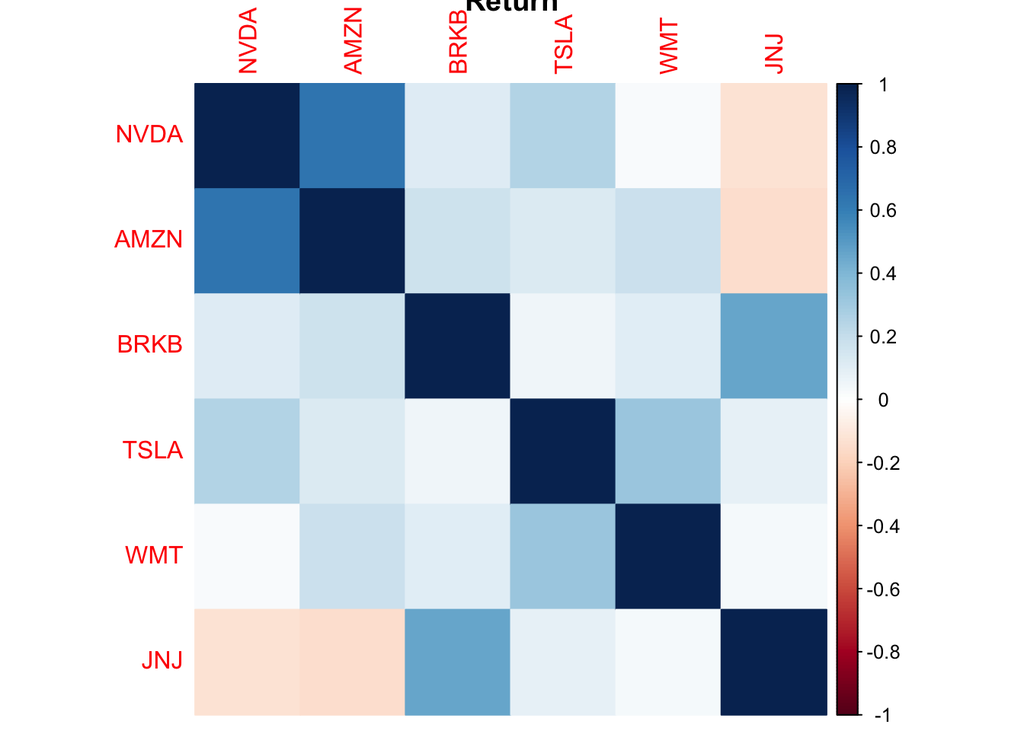

```r
##Returns

merged_returns<-inner_join(nvda_data,amzn_data,by='date',suffix=c('.nvda','.amzn'))|>inner_join(brkb_data,by="date",suffix=c(".amzn",".brkb"))|>inner_join(tsla_data,by='date',suffix=c(".brkb", ".tsla"))|>inner_join(wmt_data,by='date',suffix=c(".tsla", ".wmt"))|>inner_join(jnj_data,by='date',suffix=c(".wmt", ".jnj"))|>select(date,returns.nvda,returns.amzn,returns.brkb,returns.tsla,returns.wmt,returns.jnj)|>rename(NVDA=returns.nvda,AMZN=returns.amzn,BRKB=returns.brkb,TSLA=returns.tsla,WMT=returns.wmt,JNJ=returns.jnj)
returns_correlations <- merged_returns|>select(-date)|>cor(use="complete.obs")
returns_corr_heatmap<-returns_correlations|>corrplot(method='color',main="Return")
```

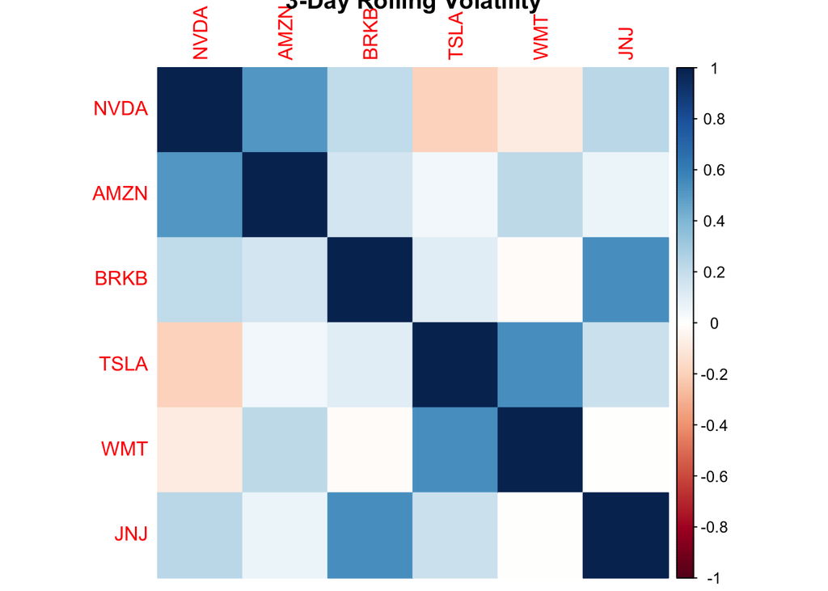

```r
##3-Day Rolling Volatilities
merged_rolling_volatilities<-inner_join(nvda_data,amzn_data,by='date',suffix=c('.nvda','.amzn'))|>inner_join(brkb_data,by="date",suffix=c(".amzn",".brkb"))|>inner_join(tsla_data,by='date',suffix=c(".brkb", ".tsla"))|>inner_join(wmt_data,by='date',suffix=c(".tsla", ".wmt"))|>inner_join(jnj_data,by='date',suffix=c(".wmt", ".jnj"))|>select(date,three_day_rolling_volatility.nvda,three_day_rolling_volatility.amzn,three_day_rolling_volatility.brkb,three_day_rolling_volatility.tsla,three_day_rolling_volatility.wmt,three_day_rolling_volatility.jnj)|>rename(NVDA=three_day_rolling_volatility.nvda,AMZN=three_day_rolling_volatility.amzn,BRKB=three_day_rolling_volatility.brkb,TSLA=three_day_rolling_volatility.tsla,WMT=three_day_rolling_volatility.wmt,JNJ=three_day_rolling_volatility.jnj)
rolling_volatilities_correlations <- merged_rolling_volatilities|>select(-date)|>cor(use="complete.obs")
rolling_volatilities_corr_heatmap<-rolling_volatilities_correlations|>corrplot(method='color',main="3-Day Rolling Volatility")
```

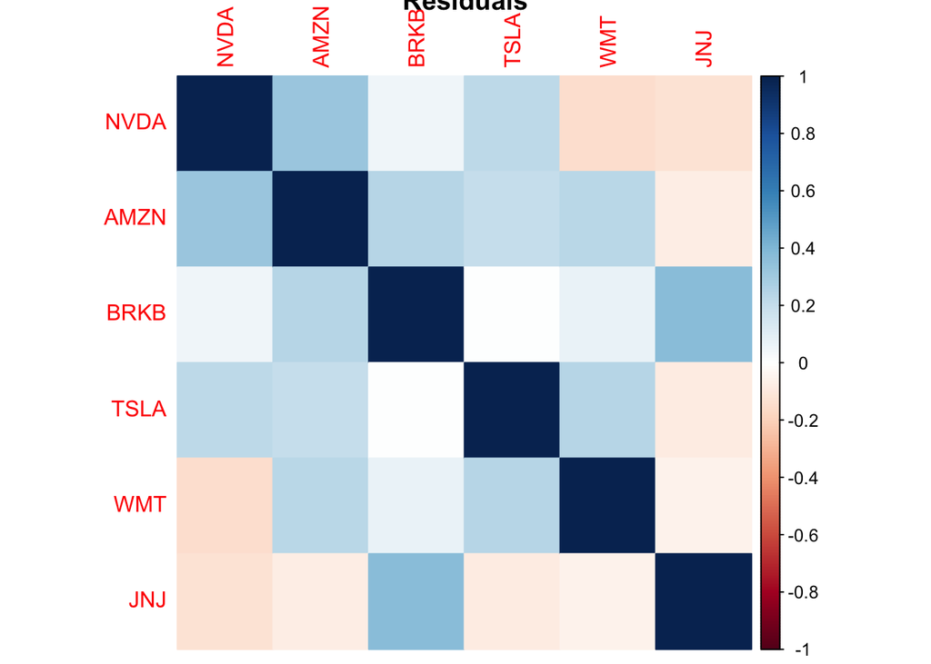

```r
##Residuals
merged_residuals<-inner_join(nvda_data,amzn_data,by='date',suffix=c('.nvda','.amzn'))|>inner_join(brkb_data,by="date",suffix=c(".amzn",".brkb"))|>inner_join(tsla_data,by='date',suffix=c(".brkb", ".tsla"))|>inner_join(wmt_data,by='date',suffix=c(".tsla", ".wmt"))|>inner_join(jnj_data,by='date',suffix=c(".wmt", ".jnj"))|>select(date,residual_decomp.nvda,residual_decomp.amzn,residual_decomp.brkb,residual_decomp.tsla,residual_decomp.wmt,residual_decomp.jnj)|>rename(NVDA=residual_decomp.nvda,AMZN=residual_decomp.amzn,BRKB=residual_decomp.brkb,TSLA=residual_decomp.tsla,WMT=residual_decomp.wmt,JNJ=residual_decomp.jnj)
residuals_correlations <- merged_residuals|>select(-date)|>cor(use="complete.obs")
residuals_corr_heatmap<-residuals_correlations|>corrplot(method='color',main="Residuals")
```

## Analysis of Correlation Heatmaps

Unlike the previous two events analyzed, the selected stocks are not well correlated with each other in the variables in the event of the Federal Reserve’s decision to hold interest rates. This event was more focused on the influence of events that allow for economic certainty on markets, which may be a reason why the stocks are not well correlated with each other. Across the GICS sectors, stock prices might increase in different behaviours when recovering from economic uncertainty, but decline in similar behaviours when faced with economic uncertainty. From the events analyzed so far in this project, the events centred around economic uncertainty resulted in stocks more correlated with each other while the current event being analyzed, centred around reducing economic uncertainty, results in stocks less correlated with each other. Such phenomenon can be observed in the time series’ as well, as stock price movements were less similar following the interest rate hold.

## Boxplots

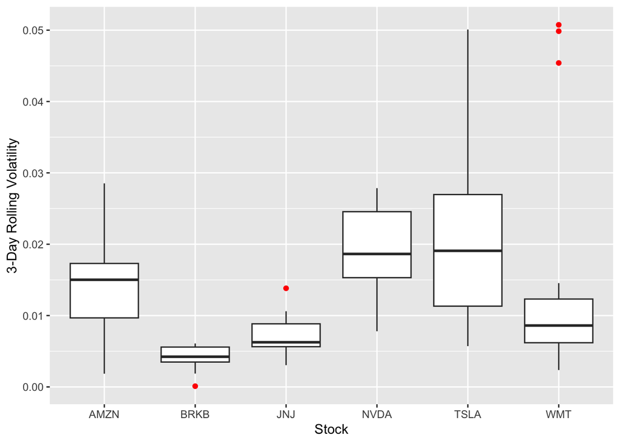

```r
##Returns

returns<-merged_returns|>select(-date)|>pivot_longer (cols=everything(),names_to="Stock",values_to="Returns")
returns_boxplot<-returns|>ggplot(aes(x=Stock,y=Returns))+geom_boxplot(outliers=TRUE,outlier.colour="red",na.rm=TRUE)+labs(x="Stock",y="Returns")
returns_pre<-merged_returns|>filter(date<="2023-12-12",date>="2023-11-13")|>select(-date)|>pivot_longer(cols=everything() ,names_to="Stock",values_to="Returns")
returns_pre_boxplot<-returns_pre|>ggplot(aes(x=Stock,y=Returns))+geom_boxplot(outliers=TRUE,outlier.colour="red",na.rm=TRUE)+labs(x="Stock",y="Returns")
returns_post<-merged_returns|>filter(date>="2023-12-14",date<="2024-01-13")|>select(-date)|>pivot_longer(cols=everything(),names_to="Stock",values_to="Returns")
returns_post_boxplot<-returns_post|>ggplot(aes(x=Stock,y=Returns))+geom_boxplot(outliers=TRUE,outlier.colour="red",na.rm=TRUE)+labs(x="Stock",y="Returns")


##3-Day Rolling Volatilities

rolling_volatilities<-merged_rolling_volatilities|>select(-date)|>pivot_longer (cols=everything(),names_to="Stock",values_to="Three_Day_Rolling_Volatility")
rolling_volatilities_boxplot<-rolling_volatilities|>ggplot(aes(x=Stock,y=Three_Day_Rolling_Volatility))+geom_boxplot(outliers=TRUE,outlier.colour="red",na.rm=TRUE)+labs(x="Stock",y="3-Day Rolling Volatility")
rolling_volatilities_pre<-merged_rolling_volatilities|>filter(date<="2023-12-12",date>="2023-11-13")|>select(-date)|>pivot_longer(cols=everything() ,names_to="Stock",values_to="Three_Day_Rolling_Volatility")
rolling_volatilities_pre_boxplot<-rolling_volatilities_pre|>ggplot(aes(x=Stock,y=Three_Day_Rolling_Volatility))+geom_boxplot(outliers=TRUE,outlier.colour="red",na.rm=TRUE)+labs(x="Stock",y="3-Day Rolling Volatility")
rolling_volatilities_post<-merged_rolling_volatilities|>filter(date>="2023-12-14",date<="2024-01-13")|>select(-date)|>pivot_longer(cols=everything(),names_to="Stock",values_to="Three_Day_Rolling_Volatility")
rolling_volatilities_post_boxplot<-rolling_volatilities_post|>ggplot(aes(x=Stock,y=Three_Day_Rolling_Volatility))+geom_boxplot(outliers=TRUE,outlier.colour="red",na.rm=TRUE)+labs(x="Stock",y="3-Day Rolling Volatility")

#amzn_data|>filter(date<="2025-05-02",date>="2025-04-03")|>ggplot(aes(x=symbol,y=three_day_rolling_volatility))+geom_boxplot(outliers=TRUE,outlier.colour="red",na.rm=TRUE)
rolling_volatilities_pre_boxplot
```

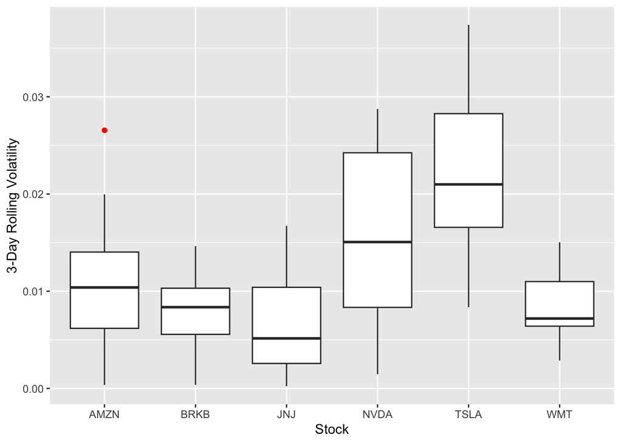

```r
rolling_volatilities_post_boxplot
```

```r
##Residuals

residuals<-merged_residuals|>select(-date)|>pivot_longer (cols=everything(),names_to="Stock",values_to="Residuals")
residuals_boxplot<-residuals|>ggplot(aes(x=Stock,y=Residuals))+geom_boxplot(outliers=TRUE,outlier.colour="red",na.rm=TRUE)+labs(x="Stock",y="Residuals")
residuals_pre<-merged_residuals|>filter(date<="2023-12-12",date>="2023-11-13")|>select(-date)|>pivot_longer(cols=everything() ,names_to="Stock",values_to="Residuals")
residuals_pre_boxplot<-residuals_pre|>ggplot(aes(x=Stock,y=Residuals))+geom_boxplot(outliers=TRUE,outlier.colour="red",na.rm=TRUE)+labs(x="Stock",y="Residuals")
residuals_post<-merged_residuals|>filter(date>="2023-12-14",date<="2024-01-13")|>select(-date)|>pivot_longer(cols=everything(),names_to="Stock",values_to="Residuals")
residuals_post_boxplot<-residuals_post|>ggplot(aes(x=Stock,y=Residuals))+geom_boxplot(outliers=TRUE,outlier.colour="red",na.rm=TRUE)+labs(x="Stock",y="Residuals")
```

## Summary Statistics

Summary statistics tables included in addition to the boxplots to have a better sense of exact figures

```r
##Returns
returns_summary<-returns|>group_by(Stock)|>summarise(median=median(Returns,na.rm=TRUE),Q1=quantile(Returns,.25,na.rm=TRUE),Q3=quantile(Returns,.75,na.rm=TRUE),min=min(Returns,na.rm=TRUE),max=max(Returns,na.rm=TRUE),IQR=Q3-Q1, range=max-min)
returns_summary_pre<-returns_pre|>group_by(Stock)|>summarise(median=median(Returns,na.rm=TRUE),Q1=quantile(Returns,.25,na.rm=TRUE),Q3=quantile(Returns,.75,na.rm=TRUE),min=min(Returns,na.rm=TRUE),max=max(Returns,na.rm=TRUE),IQR=Q3-Q1, range=max-min)
returns_summary_post<-returns_post|>group_by(Stock)|>summarise(median=median(Returns,na.rm=TRUE),Q1=quantile(Returns,.25,na.rm=TRUE),Q3=quantile(Returns,.75,na.rm=TRUE),min=min(Returns,na.rm=TRUE),max=max(Returns,na.rm=TRUE),IQR=Q3-Q1, range=max-min)

##Residuals
residuals_summary<-residuals|>group_by(Stock)|>summarise(median=median(Residuals),Q1=quantile(Residuals,.25,na.rm=TRUE),Q3=quantile(Residuals,.75,na.rm=TRUE),min=min(Residuals),max=max(Residuals),IQR=Q3-Q1, range=max-min)
residuals_summary_pre<-residuals_pre|>group_by(Stock)|>summarise(median=median(Residuals),Q1=quantile(Residuals,.25,na.rm=TRUE),Q3=quantile(Residuals,.75,na.rm=TRUE),min=min(Residuals),max=max(Residuals),IQR=Q3-Q1, range=max-min)
residuals_summary_post<-residuals_post|>group_by(Stock)|>summarise(median=median(Residuals),Q1=quantile(Residuals,.25,na.rm=TRUE),Q3=quantile(Residuals,.75,na.rm=TRUE),min=min(Residuals),max=max(Residuals),IQR=Q3-Q1, range=max-min)

##3-Day Rolling Volatility
rolling_volatilities_summary<-rolling_volatilities|>group_by(Stock)|>summarise(median=median(Three_Day_Rolling_Volatility,na.rm=TRUE),Q1=quantile(Three_Day_Rolling_Volatility,.25,na.rm=TRUE),Q3=quantile(Three_Day_Rolling_Volatility,.75,na.rm=TRUE),min=min(Three_Day_Rolling_Volatility,na.rm=TRUE),max=max(Three_Day_Rolling_Volatility,na.rm=TRUE),IQR=Q3-Q1, range=max-min)
rolling_volatilities_summary_pre<-rolling_volatilities_pre|>group_by(Stock)|>summarise(median=median(Three_Day_Rolling_Volatility,na.rm=TRUE),Q1=quantile(Three_Day_Rolling_Volatility,.25,na.rm=TRUE),Q3=quantile(Three_Day_Rolling_Volatility,.75,na.rm=TRUE),min=min(Three_Day_Rolling_Volatility,na.rm=TRUE),max=max(Three_Day_Rolling_Volatility,na.rm=TRUE),IQR=Q3-Q1, range=max-min)
rolling_volatilities_summary_post<-rolling_volatilities_post|>group_by(Stock)|>summarise(median=median(Three_Day_Rolling_Volatility,na.rm=TRUE),Q1=quantile(Three_Day_Rolling_Volatility,.25,na.rm=TRUE),Q3=quantile(Three_Day_Rolling_Volatility,.75,na.rm=TRUE),min=min(Three_Day_Rolling_Volatility),max=max(Three_Day_Rolling_Volatility),IQR=Q3-Q1, range=max-min)

rolling_volatilities_summary_pre
```

```
## # A tibble: 6 × 8
##   Stock  median      Q1      Q3      min     max     IQR   range
##   <chr>   <dbl>   <dbl>   <dbl>    <dbl>   <dbl>   <dbl>   <dbl>
## 1 AMZN  0.0150  0.00967 0.0173  0.00185  0.0285  0.00763 0.0267
## 2 BRKB  0.00423 0.00349 0.00559 0.000104 0.00609 0.00210 0.00598
## 3 JNJ   0.00626 0.00564 0.00884 0.00305  0.0138  0.00320 0.0108
## 4 NVDA  0.0186  0.0153  0.0246  0.00780  0.0279  0.00925 0.0201
## 5 TSLA  0.0191  0.0113  0.0270  0.00572  0.0501  0.0156  0.0444
## 6 WMT   0.00861 0.00619 0.0123  0.00237  0.0508  0.00613 0.0484
```

```r
rolling_volatilities_summary_post
```

```
## # A tibble: 6 × 8
##   Stock  median      Q1     Q3      min    max     IQR  range
##   <chr>   <dbl>   <dbl>  <dbl>    <dbl>  <dbl>   <dbl>  <dbl>
## 1 AMZN  0.0104  0.00618 0.0140 0.000359 0.0265 0.00785 0.0262
## 2 BRKB  0.00836 0.00556 0.0103 0.000367 0.0146 0.00475 0.0143
## 3 JNJ   0.00515 0.00257 0.0104 0.000232 0.0167 0.00783 0.0165
## 4 NVDA  0.0151  0.00834 0.0242 0.00146  0.0287 0.0159  0.0273
## 5 TSLA  0.0210  0.0166  0.0283 0.00836  0.0374 0.0117  0.0290
## 6 WMT   0.00719 0.00641 0.0110 0.00287  0.0150 0.00459 0.0122
```

With the exceptions of Walmart and Tesla, all stocks experienced an increase in the range of returns after the Federal Reserve decision. This observation makes sense as based on the time series, stock prices steadily increased to larger prices, with the exceptions of Walmart and Tesla. Tesla’s stock prices did not trend upward, but instead trended downwards, which does not expand the possible return amounts it can take on as the stock prices exhibited were similar to that of before. Taking on a larger range of stock prices allows for growth in returns, which can result in a larger range. Additionally, all stocks except Walmart and Johnson & Johnson became more volatile following the interest rate hold, which contributes to more fluctuation in returns.

Other than Johnson & Johnson, Tesla, and Walmart, all stocks experienced an increase in the range of residuals. Given that Walmart and Johnson & Johnson also faced declines in volatility following the decision, it seems like these stocks are feeling less impact from this event. As a result, in addition to the previous suggestion that they are less influenced by events creating economic uncertainty, it can be suggested that Walmart and Johnson & Johnson are also less influenced by events reducing economic uncertainty. As for Tesla, it may seem confusing that it became more volatile afterwards but the range of residuals decreased. However, based on the residual decomposition, this may be attributed to the fact that there were less frequent staunch movements in residuals prior to the interest rate hold. The frequency of such changes in residuals makes sense, as Tesla faced its own company conflicts in the early days of 2024, as previously mentioned. As a result, they face more uncertainty, which the residuals reflected.

Amazon, Johnson & Johnson, Nvidia, and Walmart experienced declines in median 3-day rolling volatility while Berkshite Hathaway and Tesla experienced increases. It may be common to assume that 3-day rolling volatilities should increase when the volatility increases, which occurred for all stocks except Walmart and Johnson & Johnson. However, if there are less sharp fluctuations in returns, than the median 3-day rolling volatility would be lower compared to a stock with a larger spread of returns and more frequent fluctuations. This is portrayed in the time series’, as there are more periods of stock price stability.